# Pertemuan 1 MPDW

Nazuwa Aulia

2023-08-29

# Packages

```r
library("forecast")
```

```r
library("graphics")
library("TTR")
library("TSA")
library(rio)
```

# Impor Data

```r
library(readxl)
data = import("https://raw.githubusercontent.com/nazuwaaulia/MPDW/main/Pertemuan%201/dataset.csv")
data
```

```
##               date rate
## 1        Juli 2013  7.3
## 2     Agustus 2013  7.2
## 3   September 2013  7.2
## 4     Oktober 2013  7.2
## 5    November 2013  6.9
## 6    Desember 2013  6.7
## 7     Januari 2014  6.6
## 8    Februari 2014  6.7
## 9       Maret 2014  6.7
## 10      April 2014  6.2
## 11        Mei 2014  6.3
## 12       Juni 2014  6.1
## 13       Juli 2014  6.2
## 14    Agustus 2014  6.1
```

[output cut: 107 more lines]

Melihat data menggunakan fungsi `View()`, struktur data menggunakan fungsi `str()`, dan dimensi data menggunakan fungsi `dim()`.

```r
View(data)
str(data)
```

```
## 'data.frame':    121 obs. of  2 variables:
##  $ date: chr  "Juli 2013" "Agustus 2013" "September 2013" "Oktober 2013" ...
##  $ rate: num  7.3 7.2 7.2 7.2 6.9 6.7 6.6 6.7 6.7 6.2 ...
```

```r
dim(data)
```

```
## [1] 121   2
```

Mengubah data agar terbaca sebagai data deret waktu dengan fungsi `ts()` .

```r
data.ts <- ts(data$rate)
```

Menampilkan ringkasan data

```r
summary(data.ts)
```

```
##    Min. 1st Qu.  Median    Mean 3rd Qu.    Max.
##   3.400   3.800   4.700   5.052   5.800  14.700
```

Membuat plot deret waktu

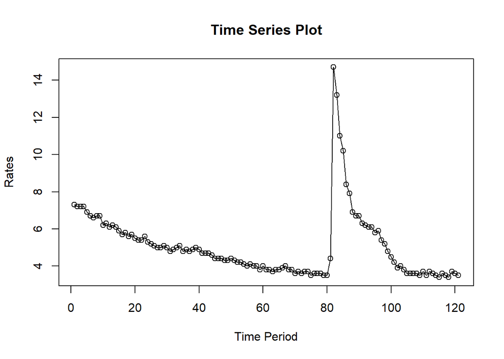

```r
ts.plot(data.ts, xlab="Time Period", ylab="Rates",
        main = "Time Series Plot")
points(data.ts)
```

Menyimpan Plot

```r
#menyimpan plot
#dev.copy(png, "eksplorasi.png")
#dev.off()
```

# Pembagian Data

Pembagian data latih dan data uji dilakukan dengan perbandingan 80% data latih dan 20% data uji.

```r
#membagi data latih dan data uji
training_ma <- data[1:97,]
testing_ma <- data[98:121,]
train_ma.ts <- ts(training_ma$rate)
test_ma.ts <- ts(testing_ma$rate)
```

## Eksplorasi Data

Melakukan Eksplorasi data pada keseluruhan data, data latih serta data uji menggunakan plot data deret waktu.

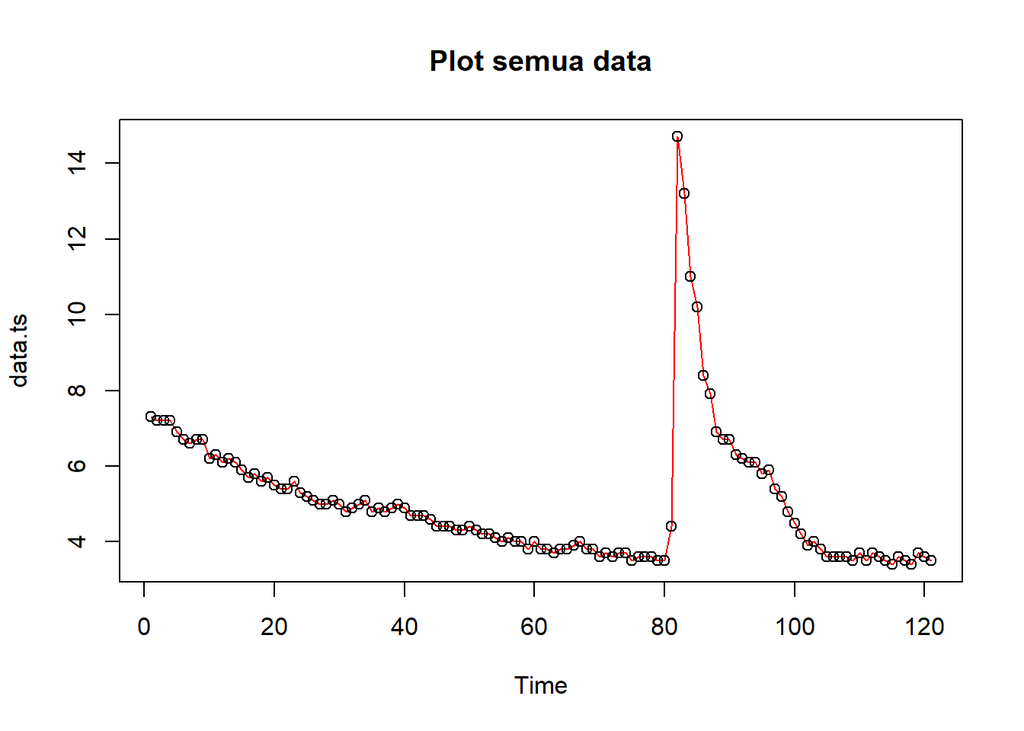

```r
#eksplorasi keseluruhan data
plot(data.ts, col="red",main="Plot semua data")
points(data.ts)
```

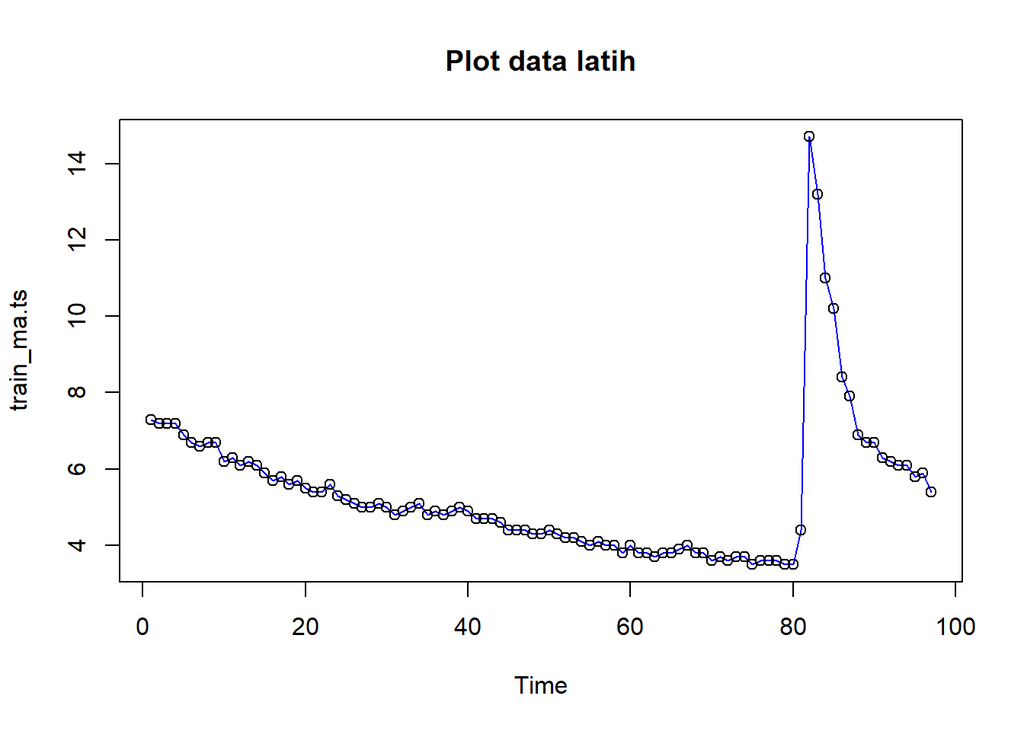

```r
#eksplorasi data latih
plot(train_ma.ts, col="blue",main="Plot data latih")
points(train_ma.ts)
```

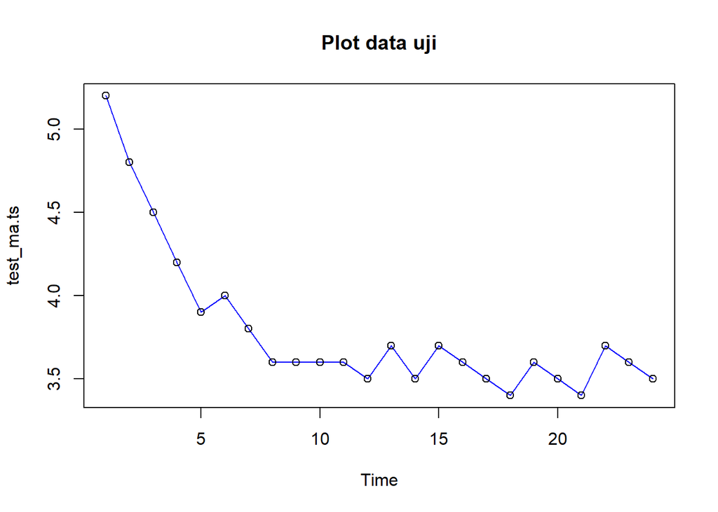

```r
#eksplorasi data uji
plot(test_ma.ts, col="blue",main="Plot data uji")
points(test_ma.ts)
```

Melakukan eksplorasi data dengan menggunakan package ggplot

```
## `geom_line()`: Each group consists of only one observation.
## ℹ Do you need to adjust the group aesthetic?
```

[figure not shown]

```r
#Eksplorasi dengan GGPLOT
library(ggplot2)
ggplot() +
  geom_line(data = training_ma, aes(x = date, y = rate, col = "Data Latih")) +
  geom_line(data = testing_ma, aes(x = date, y = rate, col = "Data Uji")) +
  labs(x = "Periode Waktu", y = "rate", color = "Legend") +
  scale_colour_manual(name="Keterangan:", breaks = c("Data Latih", "Data Uji"),
                      values = c("blue", "red")) +
  theme_bw() + theme(legend.position = "bottom",
                     plot.caption = element_text(hjust=0.5, size=12))
```

# Single Moving Average (SMA)

Ide dasar dari Single Moving Average (SMA) adalah data suatu periode dipengaruhi oleh data periode sebelumnya. Metode pemulusan ini cocok digunakan untuk pola data stasioner atau konstan. Prinsip dasar metode pemulusan ini adalah data pemulusan pada periode ke-t merupakan rata rata dari m buah data pada periode ke-t hingga periode ke (t-m+1). Data pemulusan pada periode ke-t selanjutnya digunakan sebagai nilai peramalan pada periode ke t+1

pada syntax ini digunakan n=2, hal ini disebabkan pada saat dicoba menggunakan n yang lebih besar nilai MAPE nya lebih besar dibandingkan ketika n=2

```r
data.sma<-SMA(train_ma.ts, n=2)
data.sma
```

```
## Time Series:
## Start = 1
## End = 97
## Frequency = 1
##  [1]    NA  7.25  7.20  7.20  7.05  6.80  6.65  6.65  6.70  6.45  6.25  6.20
## [13]  6.15  6.15  6.00  5.80  5.75  5.70  5.65  5.60  5.45  5.40  5.50  5.45
## [25]  5.25  5.15  5.05  5.00  5.05  5.05  4.90  4.85  4.95  5.05  4.95  4.85
## [37]  4.85  4.85  4.95  4.95  4.80  4.70  4.70  4.65  4.50  4.40  4.40  4.35
## [49]  4.30  4.35  4.35  4.25  4.20  4.15  4.05  4.05  4.05  4.00  3.90  3.90
## [61]  3.90  3.80  3.75  3.75  3.80  3.85  3.95  3.90  3.80  3.70  3.65  3.65
## [73]  3.65  3.70  3.60  3.55  3.60  3.60  3.55  3.50  3.95  9.55 13.95 12.10
## [85] 10.60  9.30  8.15  7.40  6.80  6.70  6.50  6.25  6.15  6.10  5.95  5.85
## [97]  5.65
```

Data pemulusan pada periode ke-t selanjutnya digunakan sebagai nilai peramalan pada periode ke t+1 sehingga hasil peramalan 1 periode kedepan adalah sebagai berikut.

```r
data.ramal<-c(NA,data.sma)
data.ramal #forecast 1 periode ke depan
```

```
##  [1]    NA    NA  7.25  7.20  7.20  7.05  6.80  6.65  6.65  6.70  6.45  6.25
## [13]  6.20  6.15  6.15  6.00  5.80  5.75  5.70  5.65  5.60  5.45  5.40  5.50
## [25]  5.45  5.25  5.15  5.05  5.00  5.05  5.05  4.90  4.85  4.95  5.05  4.95
## [37]  4.85  4.85  4.85  4.95  4.95  4.80  4.70  4.70  4.65  4.50  4.40  4.40
## [49]  4.35  4.30  4.35  4.35  4.25  4.20  4.15  4.05  4.05  4.05  4.00  3.90
## [61]  3.90  3.90  3.80  3.75  3.75  3.80  3.85  3.95  3.90  3.80  3.70  3.65
## [73]  3.65  3.65  3.70  3.60  3.55  3.60  3.60  3.55  3.50  3.95  9.55 13.95
## [85] 12.10 10.60  9.30  8.15  7.40  6.80  6.70  6.50  6.25  6.15  6.10  5.95
## [97]  5.85  5.65
```

Selanjutnya akan dilakukan peramalan sejumlah data uji yaitu 24 periode. Pada metode SMA, hasil peramalan 24 periode ke depan akan bernilai sama dengan hasil peramalan 1 periode kedepan. Dalam hal ini akan dilakukan penggabungan data aktual train, data hasil pemulusan dan data hasil ramalan 24 periode kedepan.

```r
data.gab<-cbind(aktual=c(train_ma.ts,rep(NA,24)),pemulusan=c(data.sma,rep(NA,24)),ramalan=c(data.ramal,rep(data.ramal[length(data.ramal)],23)))
data.gab #forecast 24 periode ke depan
```

```
##        aktual pemulusan ramalan
##   [1,]    7.3        NA      NA
##   [2,]    7.2      7.25      NA
##   [3,]    7.2      7.20    7.25
##   [4,]    7.2      7.20    7.20
##   [5,]    6.9      7.05    7.20
##   [6,]    6.7      6.80    7.05
##   [7,]    6.6      6.65    6.80
##   [8,]    6.7      6.65    6.65
##   [9,]    6.7      6.70    6.65
##  [10,]    6.2      6.45    6.70
##  [11,]    6.3      6.25    6.45
##  [12,]    6.1      6.20    6.25
##  [13,]    6.2      6.15    6.20
##  [14,]    6.1      6.15    6.15
```

[output cut: 107 more lines]

Adapun plot data deret waktu dari hasil peramalan yang dilakukan adalah sebagai berikut.

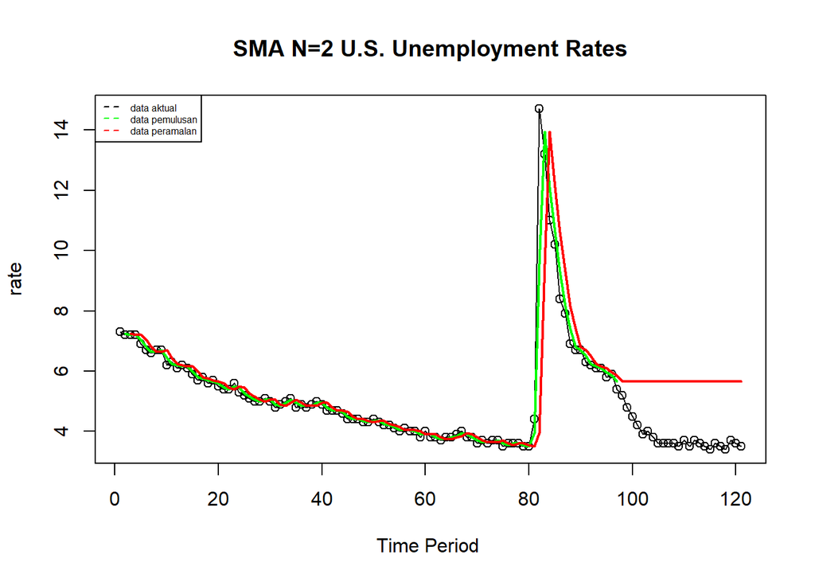

```r
ts.plot(data.ts, xlab="Time Period ", ylab="rate", main= "SMA N=2 U.S. Unemployment Rates")
points(data.ts)
lines(data.gab[,2],col="green",lwd=2)
lines(data.gab[,3],col="red",lwd=2)
legend("topleft",c("data aktual","data pemulusan","data peramalan"), lty=8, col=c("black","green","red"), cex=0.5)
```

Selanjutnya perhitungan akurasi dilakukan dengan ukuran akurasi *Sum Squares Error* (SSE), *Mean Square Error* (MSE) dan *Mean Absolute Percentage Error* (MAPE). Perhitungan akurasi dilakukan baik pada data latih maupun pada data uji.

```r
#Menghitung nilai keakuratan data latih
error_train.sma = train_ma.ts-data.ramal[1:length(train_ma.ts)]
SSE_train.sma = sum(error_train.sma[5:length(train_ma.ts)]^2)
MSE_train.sma = mean(error_train.sma[5:length(train_ma.ts)]^2)
MAPE_train.sma = mean(abs((error_train.sma[5:length(train_ma.ts)]/train_ma.ts[5:length(train_ma.ts)])*100))

akurasi_train.sma <- matrix(c(SSE_train.sma, MSE_train.sma, MAPE_train.sma))
row.names(akurasi_train.sma)<- c("SSE", "MSE", "MAPE")
colnames(akurasi_train.sma) <- c("Akurasi m = 4")
akurasi_train.sma
```

```
##      Akurasi m = 4
## SSE     153.137500
## MSE       1.646640
## MAPE      4.879552
```

Dalam hal ini nilai MAPE data latih pada metode pemulusan SMA adalah 4.87 karena nilai MAPE kurang dari 5 %, nilai ini dapat dikategorikan sebagai nilai akurasi yang sangat baik. Selanjutnya dilakukan perhitungan nilai MAPE data uji pada metode pemulusan SMA.

```r
#Menghitung nilai keakuratan data uji
error_test.sma = test_ma.ts-data.gab[98:121,3]
SSE_test.sma = sum(error_test.sma^2)
MSE_test.sma = mean(error_test.sma^2)
MAPE_test.sma = mean(abs((error_test.sma/test_ma.ts*100)))

akurasi_test.sma <- matrix(c(SSE_test.sma, MSE_test.sma, MAPE_test.sma))
row.names(akurasi_test.sma)<- c("SSE", "MSE", "MAPE")
colnames(akurasi_test.sma) <- c("Akurasi m = 4")
akurasi_test.sma
```

```
##      Akurasi m = 4
## SSE      87.620000
## MSE       3.650833
## MAPE     50.727607
```

Dalam hal ini nilai MAPE data uji pada metode pemulusan SMA adalah 50.72 karena nilai MAPE lebih dari 50 %, nilai ini dapat dikategorikan sebagai nilai akurasi yang kurang baik

# Double Moving Average (DMA)

Metode pemulusan Double Moving Average (DMA) pada dasarnya mirip dengan SMA. Namun demikian, metode ini lebih cocok digunakan untuk pola data trend. Proses pemulusan dengan rata rata dalam metode ini dilakukan sebanyak 2 kali.

```r
dma <- SMA(data.sma, n = 2)
At <- 2*data.sma - dma
Bt <- 2/(2-1)*(data.sma - dma)
data.dma<- At+Bt
data.ramal2<- c(NA, data.dma)

t = 1:24
f = c()

for (i in t) {
  f[i] = At[length(At)] + Bt[length(Bt)]*(i)
}

data.gab2 <- cbind(aktual = c(train_ma.ts,rep(NA,24)), pemulusan1 = c(data.sma,rep(NA,24)),pemulusan2 = c(data.dma, rep(NA,24)),At = c(At, rep(NA,24)), Bt = c(Bt,rep(NA,24)),ramalan = c(data.ramal2, f[-1]))
data.gab2
```

```
##        aktual pemulusan1 pemulusan2     At            Bt ramalan
##   [1,]    7.3         NA         NA     NA            NA      NA
##   [2,]    7.2       7.25         NA     NA            NA      NA
##   [3,]    7.2       7.20      7.125  7.175 -5.000000e-02      NA
##   [4,]    7.2       7.20      7.200  7.200  0.000000e+00   7.125
##   [5,]    6.9       7.05      6.825  6.975 -1.500000e-01   7.200
##   [6,]    6.7       6.80      6.425  6.675 -2.500000e-01   6.825
##   [7,]    6.6       6.65      6.425  6.575 -1.500000e-01   6.425
##   [8,]    6.7       6.65      6.650  6.650  1.776357e-15   6.425
##   [9,]    6.7       6.70      6.775  6.725  5.000000e-02   6.650
##  [10,]    6.2       6.45      6.075  6.325 -2.500000e-01   6.775
##  [11,]    6.3       6.25      5.950  6.150 -2.000000e-01   6.075
##  [12,]    6.1       6.20      6.125  6.175 -5.000000e-02   5.950
##  [13,]    6.2       6.15      6.075  6.125 -5.000000e-02   6.125
##  [14,]    6.1       6.15      6.150  6.150  0.000000e+00   6.075
```

[output cut: 107 more lines]

Hasil pemulusan menggunakan metode DMA divisualisasikan sebagai berikut

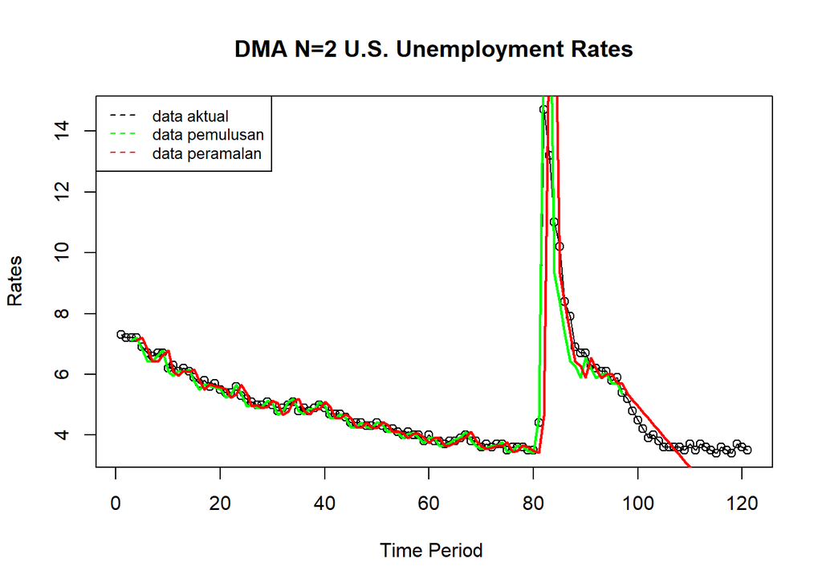

```r
ts.plot(data.ts, xlab="Time Period ", ylab="Rates", main= "DMA N=2 U.S. Unemployment Rates")
points(data.ts)
lines(data.gab2[,3],col="green",lwd=2)
lines(data.gab2[,6],col="red",lwd=2)
legend("topleft",c("data aktual","data pemulusan","data peramalan"), lty=8, col=c("black","green","red"), cex=0.8)
```

Selanjutnya perhitungan akurasi dilakukan baik pada data latih maupun data uji. Perhitungan akurasi dilakukan dengan ukuran akurasi SSE, MSE dan MAPE.

```r
#Menghitung nilai keakuratan data latih
error_train.dma = train_ma.ts-data.ramal2[1:length(train_ma.ts)]
SSE_train.dma = sum(error_train.dma[8:length(train_ma.ts)]^2)
MSE_train.dma = mean(error_train.dma[8:length(train_ma.ts)]^2)
MAPE_train.dma = mean(abs((error_train.dma[8:length(train_ma.ts)]/train_ma.ts[8:length(train_ma.ts)])*100))

akurasi_train.dma <- matrix(c(SSE_train.dma, MSE_train.dma, MAPE_train.dma))
row.names(akurasi_train.dma)<- c("SSE", "MSE", "MAPE")
colnames(akurasi_train.dma) <- c("Akurasi m = 4")
akurasi_train.dma
```

```
##      Akurasi m = 4
## SSE     220.754375
## MSE       2.452826
## MAPE      5.446481
```

Dalam hal ini nilai MAPE data latih pada metode pemulusan DMA adalah 5.44 karena nilai MAPE kurang dari 10 %, nilai ini dapat dikategorikan sebagai nilai akurasi yang sangat baik. Selanjutnya dilakukan perhitungan nilai MAPE data uji pada metode pemulusan DMA.

```r
#Menghitung nilai keakuratan data uji
error_test.dma = test_ma.ts-data.gab2[98:121,6]
SSE_test.dma = sum(error_test.dma^2)
MSE_test.dma = mean(error_test.dma^2)
MAPE_test.dma = mean(abs((error_test.dma/test_ma.ts*100)))

akurasi_test.dma <- matrix(c(SSE_test.dma, MSE_test.dma, MAPE_test.dma))
row.names(akurasi_test.dma)<- c("SSE", "MSE", "MAPE")
colnames(akurasi_test.dma) <- c("Akurasi n = 2")
akurasi_test.dma
```

```
##      Akurasi n = 2
## SSE      42.100000
## MSE       1.754167
## MAPE     28.222513
```

Dalam hal ini nilai MAPE data uji pada metode pemulusan DMA adalah 28.22 karena nilai MAPE kurang dari 50 %, nilai ini dapat dikategorikan sebagai nilai akurasi yang baik

Setelah dilakukan dua metode pemulusan pada data dapat diambil kesimpulan bahwa metode pemulusan data lebih baik menggunakan Double Moving Average(DMA) jika dilihat dari nilai MAPE nya hal tersebut mendukung pernyataan bahwa DMA digunakan untuk metode pemulusan pola data trend sedangkan SMA digunakan untuk pola data stasioner

# Single Exponential Smoothing & Double Exponential Smoothing

Metode *Exponential Smoothing* adalah metode pemulusan dengan melakukan pembobotan menurun secara eksponensial. Nilai yang lebih baru diberi bobot yang lebih besar dari nilai terdahulu. Terdapat satu atau lebih parameter pemulusan yang ditentukan secara eksplisit, dan hasil pemilihan parameter tersebut akan menentukan bobot yang akan diberikan pada nilai pengamatan. Ada dua macam model, yaitu model tunggal dan ganda.

## SES

Single Exponential Smoothing merupakan metode pemulusan yang tepat digunakan untuk data dengan pola stasioner atau konstan.

Nilai parameter $\lambda$ adalah nilai antara 0 dan 1.

Nilai pemulusan periode ke-t bertindak sebagai nilai ramalan pada periode ke-$(T+\tau)$.

Pemulusan dengan metode SES dapat dilakukan dengan dua fungsi dari *packages* berbeda, yaitu (1) fungsi `ses()` dari *packages* `forecast` dan (2) fungsi `HoltWinters` dari *packages* `stats` .

Input data yang sama hanya beda penamaan

```r
#membagi training dan testing
training<-data[1:97,]
testing<-data[98:121,]
train.ts <- ts(training$rate)
test.ts <- ts(testing$rate)
```

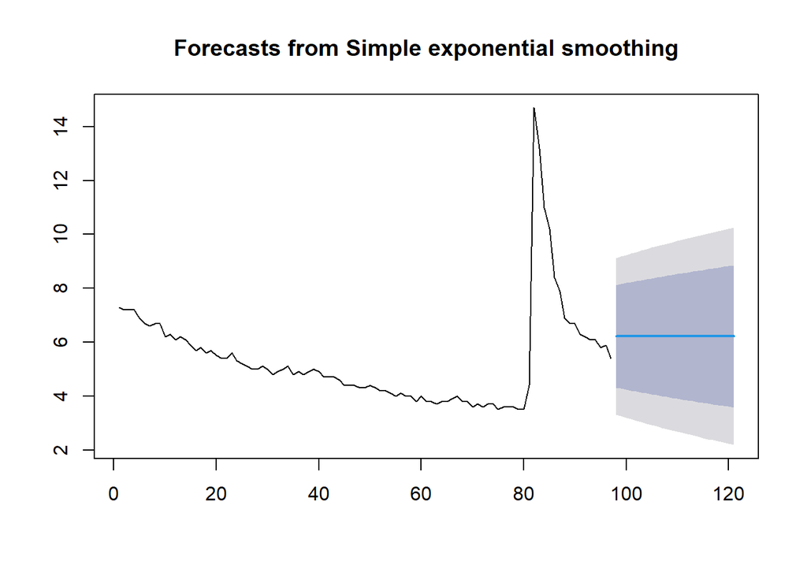

```r
#Cara 1 (fungsi ses)
ses.1 <- ses(train.ts, h = 24, alpha = 0.2)
plot(ses.1)
```

```r
ses.1
```

```
##     Point Forecast    Lo 80    Hi 80    Lo 95     Hi 95
##  98       6.218738 4.316918 8.120559 3.310155  9.127322
##  99       6.218738 4.279254 8.158222 3.252553  9.184923
## 100       6.218738 4.242308 8.195168 3.196050  9.241427
## 101       6.218738 4.206041 8.231436 3.140583  9.296894
## 102       6.218738 4.170415 8.267062 3.086098  9.351379
## 103       6.218738 4.135398 8.302078 3.032545  9.404932
## 104       6.218738 4.100961 8.336516 2.979877  9.457600
## 105       6.218738 4.067074 8.370403 2.928052  9.509425
## 106       6.218738 4.033713 8.403764 2.877030  9.560447
## 107       6.218738 4.000853 8.436623 2.826776  9.610701
## 108       6.218738 3.968474 8.469003 2.777256  9.660221
## 109       6.218738 3.936554 8.500923 2.728438  9.709039
## 110       6.218738 3.905074 8.532403 2.680294  9.757183
## 111       6.218738 3.874016 8.563460 2.632796  9.804681
## 112       6.218738 3.843365 8.594112 2.585919  9.851558
## 113       6.218738 3.813104 8.624372 2.539639  9.897838
## 114       6.218738 3.783220 8.654257 2.493934  9.943543
## 115       6.218738 3.753697 8.683780 2.448783  9.988694
## 116       6.218738 3.724524 8.712953 2.404167 10.033310
## 117       6.218738 3.695688 8.741789 2.360066 10.077411
## 118       6.218738 3.667178 8.770298 2.316464 10.121013
## 119       6.218738 3.638983 8.798493 2.273344 10.164133
## 120       6.218738 3.611093 8.826383 2.230689 10.206787
## 121       6.218738 3.583498 8.853978 2.188487 10.248990
```

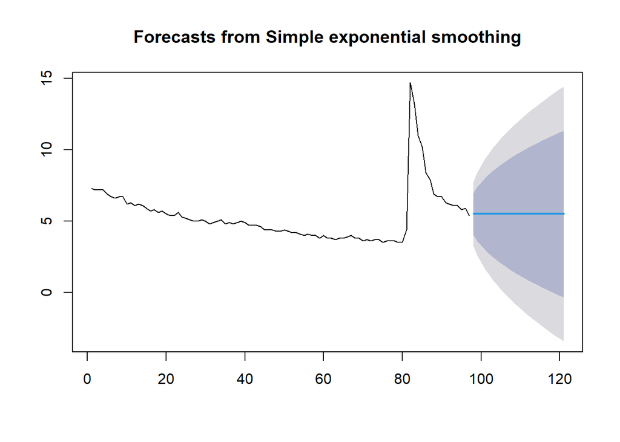

```r
ses.2<- ses(train.ts, h = 24, alpha = 0.8)
plot(ses.2)
```

```r
ses.2
```

```
##     Point Forecast       Lo 80     Hi 80       Lo 95     Hi 95
##  98       5.498444  4.02558018  6.971307  3.24589331  7.750994
##  99       5.498444  3.61225807  7.384629  2.61377169  8.383116
## 100       5.498444  3.27446854  7.722419  2.09716718  8.899720
## 101       5.498444  2.98161339  8.015274  1.64928388  9.347604
## 102       5.498444  2.71945034  8.277437  1.24834009  9.748547
## 103       5.498444  2.47997167  8.516916  0.88208907 10.114798
## 104       5.498444  2.25814391  8.738744  0.54283280 10.454055
## 105       5.498444  2.05055855  8.946329  0.22535838 10.771529
## 106       5.498444  1.85478053  9.142107 -0.07405827 11.070946
## 107       5.498444  1.66899849  9.327889 -0.35818738 11.355075
## 108       5.498444  1.49182169  9.505066 -0.62915591 11.626043
## 109       5.498444  1.32215477  9.674733 -0.88863907 11.885527
## 110       5.498444  1.15911673  9.837771 -1.13798423 12.134872
## 111       5.498444  1.00198644  9.994901 -1.37829427 12.375182
## 112       5.498444  0.85016475 10.146723 -1.61048551 12.607373
## 113       5.498444  0.70314741 10.293740 -1.83532912 12.832217
## 114       5.498444  0.56050529 10.436382 -2.05348143 13.050369
## 115       5.498444  0.42186955 10.575018 -2.26550649 13.262394
## 116       5.498444  0.28692047 10.709967 -2.47189331 13.468781
## 117       5.498444  0.15537869 10.841509 -2.67306910 13.669957
## 118       5.498444  0.02699846 10.969889 -2.86940971 13.866297
## 119       5.498444 -0.09843778 11.095325 -3.06124789 14.058135
## 120       5.498444 -0.22112373 11.218011 -3.24887986 14.245767
## 121       5.498444 -0.34123274 11.338120 -3.43257074 14.429458
```

Untuk mendapatkan gambar hasil pemulusan pada data latih dengan fungsi `ses()` , perlu digunakan fungsi `autoplot()` dan `autolayer()` dari *library packages* `ggplot2` .

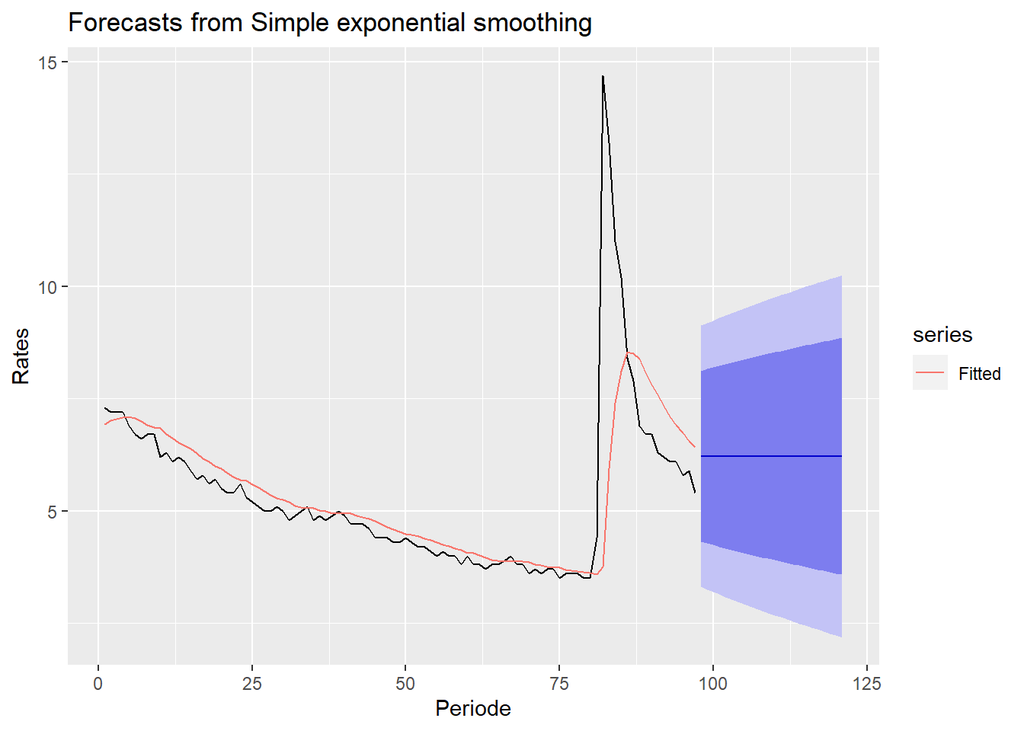

```r
autoplot(ses.1) +
  autolayer(fitted(ses.1), series="Fitted") +
  ylab("Rates") + xlab("Periode")
```

Pada fungsi `ses()` , terdapat beberapa argumen yang umum digunakan, yaitu nilai `y` , `gamma` , `beta` , `alpha` , dan `h` .

Nilai `y` adalah nilai data deret waktu, `gamma` adalah parameter pemulusan untuk komponen musiman, `beta` adalah parameter pemulusan untuk tren, dan `alpha` adalah parameter pemulusan untuk stasioner, serta `h` adalah banyaknya periode yang akan diramalkan.

Selanjutnya akan digunakan fungsi `HoltWinters()` dengan nilai inisialisasi parameter dan panjang periode peramalan yang sama dengan fungsi `ses()` .

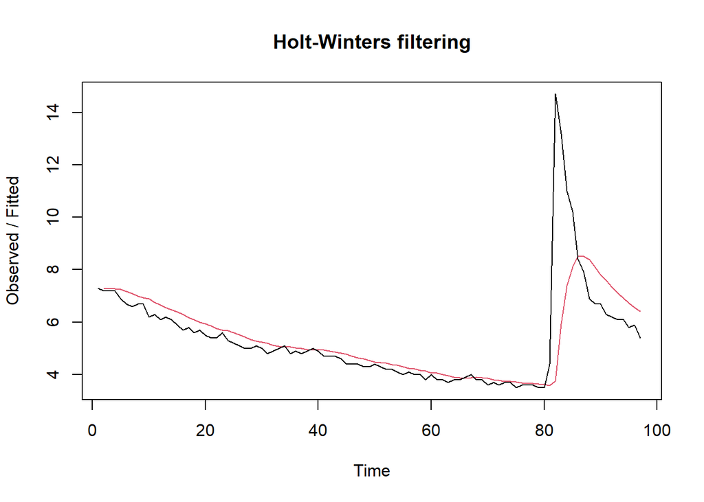

```r
#Cara 2 (fungsi Holtwinter)
ses1<- HoltWinters(train.ts, gamma = FALSE, beta = FALSE, alpha = 0.2)
plot(ses1)
```

```r
#ramalan
ramalan1<- forecast(ses1, h=24)
ramalan1
```

```
##     Point Forecast    Lo 80    Hi 80    Lo 95     Hi 95
##  98       6.218738 4.316600 8.120877 3.309668  9.127809
##  99       6.218738 4.278930 8.158547 3.252057  9.185420
## 100       6.218738 4.241978 8.195499 3.195544  9.241933
## 101       6.218738 4.205704 8.231773 3.140068  9.297409
## 102       6.218738 4.170072 8.267405 3.085574  9.351903
## 103       6.218738 4.135050 8.302427 3.032011  9.405465
## 104       6.218738 4.100606 8.336871 2.979335  9.458142
## 105       6.218738 4.066714 8.370763 2.927501  9.509976
## 106       6.218738 4.033347 8.404130 2.876471  9.561006
## 107       6.218738 4.000482 8.436994 2.826209  9.611268
## 108       6.218738 3.968097 8.469379 2.776680  9.660797
## 109       6.218738 3.936172 8.501305 2.727854  9.709623
## 110       6.218738 3.904687 8.532790 2.679702  9.757775
## 111       6.218738 3.873624 8.563853 2.632196  9.805281
## 112       6.218738 3.842968 8.594509 2.585311  9.852166
## 113       6.218738 3.812702 8.624775 2.539023  9.898454
## 114       6.218738 3.782812 8.654665 2.493311  9.944166
## 115       6.218738 3.753285 8.684192 2.448152  9.989324
## 116       6.218738 3.724107 8.713370 2.403528 10.033948
## 117       6.218738 3.695266 8.742211 2.359420 10.078056
## 118       6.218738 3.666751 8.770725 2.315811 10.121666
## 119       6.218738 3.638552 8.798925 2.272683 10.164793
## 120       6.218738 3.610657 8.826820 2.230022 10.207455
## 121       6.218738 3.583057 8.854419 2.187812 10.249664
```

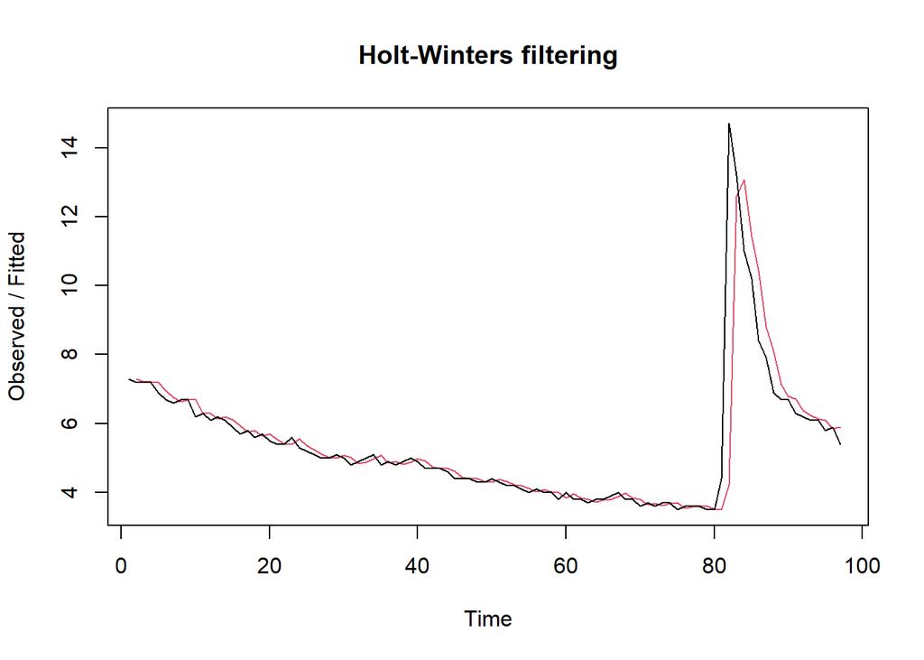

```r
ses2<- HoltWinters(train.ts, gamma = FALSE, beta = FALSE, alpha = 0.8)
plot(ses2)
```

```r
#ramalan
ramalan2<- forecast(ses2, h=24)
ramalan2
```

```
##     Point Forecast       Lo 80     Hi 80       Lo 95     Hi 95
##  98       5.498444  4.02588767  6.971000  3.24636357  7.750524
##  99       5.498444  3.61265185  7.384236  2.61437392  8.382514
## 100       5.498444  3.27493283  7.721955  2.09787726  8.899010
## 101       5.498444  2.98213882  8.014749  1.65008746  9.346800
## 102       5.498444  2.72003050  8.276857  1.24922738  9.747660
## 103       5.498444  2.48060183  8.516286  0.88305282 10.113835
## 104       5.498444  2.25882038  8.738067  0.54386737 10.453020
## 105       5.498444  2.05127836  8.945609  0.22645923 10.770428
## 106       5.498444  1.85554121  9.141346 -0.07289491 11.069782
## 107       5.498444  1.66979795  9.327090 -0.35696470 11.353852
## 108       5.498444  1.49265814  9.504229 -0.62787666 11.624764
## 109       5.498444  1.32302664  9.673861 -0.88730565 11.884193
## 110       5.498444  1.16002264  9.836865 -1.13659876 12.133486
## 111       5.498444  1.00292516  9.993962 -1.37685863 12.373746
## 112       5.498444  0.85113516 10.145752 -1.60900139 12.605889
## 113       5.498444  0.70414852 10.292739 -1.83379807 12.830686
## 114       5.498444  0.56153617 10.435351 -2.05190484 13.048792
## 115       5.498444  0.42292938 10.573958 -2.26388563 13.260773
## 116       5.498444  0.28800847 10.708879 -2.47022936 13.467117
## 117       5.498444  0.15649415 10.840393 -2.67136315 13.668251
## 118       5.498444  0.02814072 10.968747 -2.86766278 13.864550
## 119       5.498444 -0.09726933 11.094157 -3.05946091 14.056348
## 120       5.498444 -0.21992967 11.216817 -3.24705371 14.243941
## 121       5.498444 -0.34001361 11.336901 -3.43070623 14.427594
```

Fungsi `HoltWinters` memiliki argumen yang sama dengan fungsi `ses()` . Argumen-argumen kedua fungsi dapat dilihat lebih lanjut dengan `?ses()` atau `?HoltWinters` .

Nilai parameter $\alpha$ dari kedua fungsi dapat dioptimalkan menyesuaikan dari *error*-nya paling minimumnya. Caranya adalah dengan membuat parameter $\alpha =$ `NULL` .

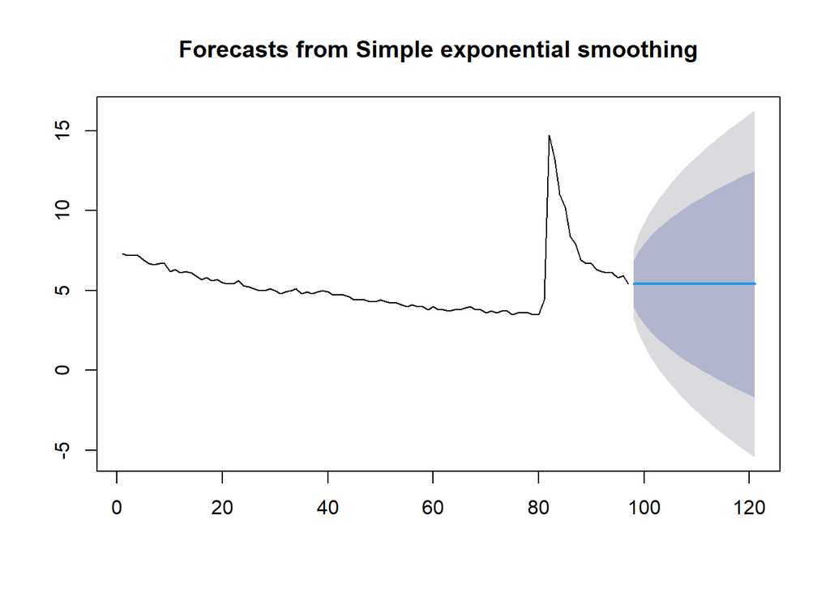

```r
#SES
ses.opt <- ses(train.ts, h = 24, alpha = NULL)
plot(ses.opt)
```

```r
ses.opt
```

```
##     Point Forecast       Lo 80     Hi 80       Lo 95     Hi 95
##  98        5.40005  3.95222610  6.847874  3.18579433  7.614306
##  99        5.40005  3.35262048  7.447480  2.26877667  8.531324
## 100        5.40005  2.89251310  7.907587  1.56510316  9.234997
## 101        5.40005  2.50461999  8.295480  0.97187183  9.828229
## 102        5.40005  2.16287706  8.637223  0.44922112 10.350879
## 103        5.40005  1.85391656  8.946184 -0.02329318 10.823394
## 104        5.40005  1.56979726  9.230303 -0.45781616 11.257917
## 105        5.40005  1.30534491  9.494755 -0.86226113 11.662361
## 106        5.40005  1.05696544  9.743135 -1.24212475 12.042225
## 107        5.40005  0.82204200  9.978058 -1.60140914 12.401510
## 108        5.40005  0.59859907 10.201501 -1.94313561 12.743236
## 109        5.40005  0.38510187 10.414998 -2.26965140 13.069752
## 110        5.40005  0.18032985 10.619771 -2.58282319 13.382924
## 111        5.40005 -0.01670661 10.816807 -2.88416445 13.684265
## 112        5.40005 -0.20682310 11.006923 -3.17492253 13.975023
## 113        5.40005 -0.39070122 11.190802 -3.45613985 14.256240
## 114        5.40005 -0.56891754 11.369018 -3.72869818 14.528799
## 115        5.40005 -0.74196492 11.542065 -3.99335131 14.793452
## 116        5.40005 -0.91026861 11.710369 -4.25074960 15.050850
## 117        5.40005 -1.07419859 11.874299 -4.50145886 15.301559
## 118        5.40005 -1.23407907 12.034179 -4.74597496 15.546075
## 119        5.40005 -1.39019611 12.190296 -4.98473537 15.784836
## 120        5.40005 -1.54280359 12.342904 -5.21812837 16.018229
## 121        5.40005 -1.69212807 12.492228 -5.44650045 16.246601
```

```r
#Lamda Optimum Holt Winter
sesopt<- HoltWinters(train.ts, gamma = FALSE, beta = FALSE,alpha = NULL)
sesopt
```

```
## Holt-Winters exponential smoothing without trend and without seasonal component.
##
## Call:
## HoltWinters(x = train.ts, alpha = NULL, beta = FALSE, gamma = FALSE)
##
## Smoothing parameters:
##  alpha: 0.9999258
##  beta : FALSE
##  gamma: FALSE
##
## Coefficients:
##       [,1]
## a 5.400037
```

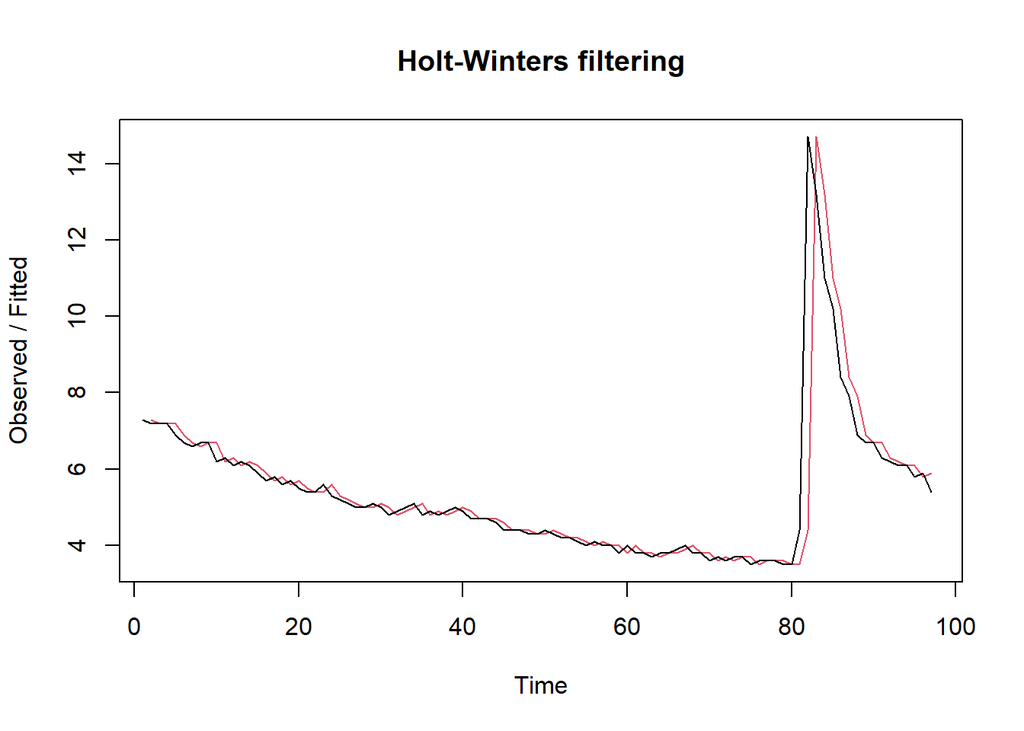

```r
plot(sesopt)
```

```r
#ramalan
ramalanopt<- forecast(sesopt, h=24)
ramalanopt
```

```
##     Point Forecast      Lo 80     Hi 80       Lo 95     Hi 95
##  98       5.400037  3.9524382  6.847636  3.18612570  7.613949
##  99       5.400037  3.3528991  7.447175  2.26920975  8.530864
## 100       5.400037  2.8928464  7.907228  1.56561979  9.234454
## 101       5.400037  2.5050005  8.295074  0.97246075  9.827613
## 102       5.400037  2.1632998  8.636774  0.44987462 10.350200
## 103       5.400037  1.8543778  8.945696 -0.02258079 10.822655
## 104       5.400037  1.5702942  9.229780 -0.45704930 11.257124
## 105       5.400037  1.3058751  9.494199 -0.86144334 11.661518
## 106       5.400037  1.0575270  9.742547 -1.24125897 12.041333
## 107       5.400037  0.8226333  9.977441 -1.60049786 12.400572
## 108       5.400037  0.5992188 10.200855 -1.94218095 12.742255
## 109       5.400037  0.3857487 10.414326 -2.26865524 13.068729
## 110       5.400037  0.1810027 10.619071 -2.58178715 13.381861
## 111       5.400037 -0.0160086 10.816083 -2.88309001 13.683164
## 112       5.400037 -0.2061008 11.006175 -3.17381098 13.973885
## 113       5.400037 -0.3899555 11.190030 -3.45499238 14.255067
## 114       5.400037 -0.5681490 11.368223 -3.72751588 14.527590
## 115       5.400037 -0.7411742 11.541248 -3.99213515 14.792209
## 116       5.400037 -0.9094564 11.709531 -4.24950049 15.049575
## 117       5.400037 -1.0733654 11.873440 -4.50017765 15.300252
## 118       5.400037 -1.2332254 12.033300 -4.74466242 15.544737
## 119       5.400037 -1.3893224 12.189397 -4.98339222 15.783466
## 120       5.400037 -1.5419103 12.341985 -5.21675529 16.016830
## 121       5.400037 -1.6912156 12.491290 -5.44509807 16.245172
```

Setelah dilakukan peramalan, akan dilakukan perhitungan keakuratan hasil peramalan. Perhitungan akurasi ini dilakukan baik pada data latih dan data uji.

### Akurasi Data Latih

Perhitungan akurasi data dapat dilakukan dengan cara langsung maupun manual. Secara langsung, nilai akurasi dapat diambil dari objek yang tersimpan pada hasil SES, yaitu *sum of squared errors* (SSE). Nilai akurasi lain dapat dihitung pula dari nilai SSE tersebut.

```r
#Keakuratan Metode
#Pada data training
SSE1<-ses1$SSE
MSE1<-ses1$SSE/length(train.ts)
RMSE1<-sqrt(MSE1)

akurasi1 <- matrix(c(SSE1,MSE1,RMSE1))
row.names(akurasi1)<- c("SSE", "MSE", "RMSE")
colnames(akurasi1) <- c("Akurasi lamda=0.2")
akurasi1
```

```
##      Akurasi lamda=0.2
## SSE         209.588382
## MSE           2.160705
## RMSE          1.469934
```

```r
SSE2<-ses2$SSE
MSE2<-ses2$SSE/length(train.ts)
RMSE2<-sqrt(MSE2)

akurasi2 <- matrix(c(SSE2,MSE2,RMSE2))
row.names(akurasi2)<- c("SSE", "MSE", "RMSE")
colnames(akurasi2) <- c("Akurasi lamda=0.8")
akurasi2
```

```
##      Akurasi lamda=0.8
## SSE         125.481004
## MSE           1.293619
## RMSE          1.137374
```

```r
#Cara Manual
fitted1<-ramalan1$fitted
sisaan1<-ramalan1$residuals
head(sisaan1)
```

```
## Time Series:
## Start = 1
## End = 6
## Frequency = 1
## [1]       NA -0.10000 -0.08000 -0.06400 -0.35120 -0.48096
```

```r
resid1<-training$rate-ramalan1$fitted
head(resid1)
```

```
## Time Series:
## Start = 1
## End = 6
## Frequency = 1
## [1]       NA -0.10000 -0.08000 -0.06400 -0.35120 -0.48096
```

Untuk melihat nilai MAPE dapat menggunakan cara manual

```r
SSE.1=sum(sisaan1[2:length(train.ts)]^2)
SSE.1
```

```
## [1] 209.5884
```

```r
MSE.1 = SSE.1/length(train.ts)
MSE.1
```

```
## [1] 2.160705
```

```r
MAPE.1 = sum(abs(sisaan1[2:length(train.ts)]/train.ts[2:length(train.ts)])*
               100)/length(train.ts)
MAPE.1
```

```
## [1] 7.943529
```

```r
akurasi.1 <- matrix(c(SSE.1,MSE.1,MAPE.1))
row.names(akurasi.1)<- c("SSE", "MSE", "MAPE")
colnames(akurasi.1) <- c("Akurasi lamda=0.2")
akurasi.1
```

```
##      Akurasi lamda=0.2
## SSE         209.588382
## MSE           2.160705
## MAPE          7.943529
```

```r
fitted2<-ramalan2$fitted
sisaan2<-ramalan2$residuals
head(sisaan2)
```

```
## Time Series:
## Start = 1
## End = 6
## Frequency = 1
## [1]       NA -0.10000 -0.02000 -0.00400 -0.30080 -0.26016
```

```r
resid2<-training$rate-ramalan2$fitted
head(resid2)
```

```
## Time Series:
## Start = 1
## End = 6
## Frequency = 1
## [1]       NA -0.10000 -0.02000 -0.00400 -0.30080 -0.26016
```

```r
SSE.2=sum(sisaan2[2:length(train.ts)]^2)
SSE.2
```

```
## [1] 125.481
```

```r
MSE.2 = SSE.2/length(train.ts)
MSE.2
```

```
## [1] 1.293619
```

```r
MAPE.2 = sum(abs(sisaan2[2:length(train.ts)]/train.ts[2:length(train.ts)])*
               100)/length(train.ts)
MAPE.2
```

```
## [1] 4.08248
```

```r
akurasi.2 <- matrix(c(SSE.2,MSE.2,MAPE.2))
row.names(akurasi.2)<- c("SSE", "MSE", "MAPE")
colnames(akurasi.2) <- c("Akurasi lamda=0.8")
akurasi.2
```

```
##      Akurasi lamda=0.8
## SSE         125.481004
## MSE           1.293619
## MAPE          4.082480
```

Berdasarkan nilai SSE, MSE, RMSE, dan MAPE di antara kedua parameter, nilai parameter $\lambda=0.8$ menghasilkan akurasi yang lebih baik dibanding $\lambda=0.2$ . Hal ini dilihat dari nilai masing-masing ukuran akurasi yang lebih kecil. Berdasarkan nilai MAPE-nya, hasil ini dapat dikategorikan sebagai peramalan sangat baik karena nilai MAPE kurang dari 10%.

### Akurasi Data Uji

Akurasi data uji dapat dihitung dengan cara yang hampir sama dengan perhitungan akurasi data latih.

```r
selisih1<-ramalan1$mean-testing$rate
SSEtesting1<-sum(selisih1^2)
MSEtesting1<-SSEtesting1/length(testing)

selisih2<-ramalan2$mean-testing$rate
SSEtesting2<-sum(selisih2^2)
MSEtesting2<-SSEtesting2/length(testing)

selisihopt<-ramalanopt$mean-testing$rate
SSEtestingopt<-sum(selisihopt^2)
MSEtestingopt<-SSEtestingopt/length(testing)

akurasitesting1 <- matrix(c(SSEtesting1,SSEtesting2,SSEtestingopt))
row.names(akurasitesting1)<- c("SSE1", "SSE2", "SSEopt")
akurasitesting1
```

```
##             [,1]
## SSE1   146.11458
## SSE2    74.65245
## SSEopt  66.82286
```

```r
akurasitesting2 <- matrix(c(MSEtesting1,MSEtesting2,MSEtestingopt))
row.names(akurasitesting2)<- c("MSE1", "MSE2", "MSEopt")
akurasitesting2
```

```
##            [,1]
## MSE1   73.05729
## MSE2   37.32622
## MSEopt 33.41143
```

## DES

Metode pemulusan *Double Exponential Smoothing* (DES) digunakan untuk data yang memiliki pola tren. Metode DES adalah metode semacam SES, hanya saja dilakukan dua kali, yaitu pertama untuk tahapan ‘level’ dan kedua untuk tahapan ‘tren’. Pemulusan menggunakan metode ini akan menghasilkan peramalan tidak konstan untuk periode berikutnya.

Pemulusan dengan metode DES kali ini akan menggunakan fungsi `HoltWinters()` . Jika sebelumnya nilai argumen `beta` dibuat `FALSE` , kali ini argumen tersebut akan diinisialisasi bersamaan dengan nilai `alpha` .

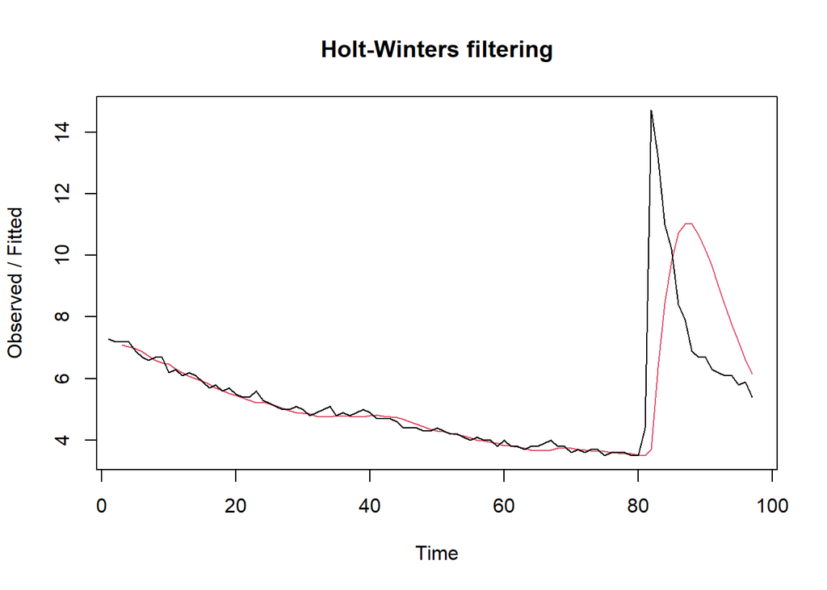

```r
#Lamda=0.2 dan gamma=0.2
des.1<- HoltWinters(train.ts, gamma = FALSE, beta = 0.2, alpha = 0.2)
plot(des.1)
```

```r
#ramalan
ramalandes1<- forecast(des.1, h=24)
ramalandes1
```

```
##     Point Forecast       Lo 80    Hi 80       Lo 95    Hi 95
##  98     5.65332602   3.4966028 7.810049   2.3549025 8.951750
##  99     5.30377283   3.0858056 7.521740   1.9116846 8.695861
## 100     4.95421964   2.6555129 7.252926   1.4386510 8.469788
## 101     4.60466645   2.2045911 7.004742   0.9340679 8.275265
## 102     4.25511326   1.7325768 6.777650   0.3972266 8.113000
## 103     3.90556007   1.2395850 6.571535  -0.1716970 7.982817
## 104     3.55600688   0.7261756 6.385838  -0.7718465 7.883860
## 105     3.20645369   0.1932096 6.219698  -1.4019055 7.814813
## 106     2.85690049  -0.3582812 6.072082  -2.0602956 7.774097
## 107     2.50734730  -0.9271963 5.941891  -2.7453338 7.760028
## 108     2.15779411  -1.5124393 5.828028  -3.4553435 7.770932
## 109     1.80824092  -2.1129642 5.729446  -4.1887248 7.805207
## 110     1.45868773  -2.7278003 5.645176  -4.9439932 7.861369
## 111     1.10913454  -3.3560638 5.574333  -5.7197971 7.938066
## 112     0.75958135  -3.9969591 5.516122  -6.5149195 8.034082
## 113     0.41002816  -4.6497750 5.469831  -7.3282730 8.148329
## 114     0.06047497  -5.3138784 5.434828  -8.1588893 8.279839
## 115    -0.28907823  -5.9887064 5.410550  -9.0059073 8.427751
## 116    -0.63863142  -6.6737580 5.396495  -9.8685610 8.591298
## 117    -0.98818461  -7.3685869 5.392218 -10.7461679 8.769799
## 118    -1.33773780  -8.0727945 5.397319 -11.6381181 8.962643
## 119    -1.68729099  -8.7860234 5.411441 -12.5438654 9.169283
## 120    -2.03684418  -9.5079525 5.434264 -13.4629183 9.389230
## 121    -2.38639737 -10.2382917 5.465497 -14.3948335 9.622039
```

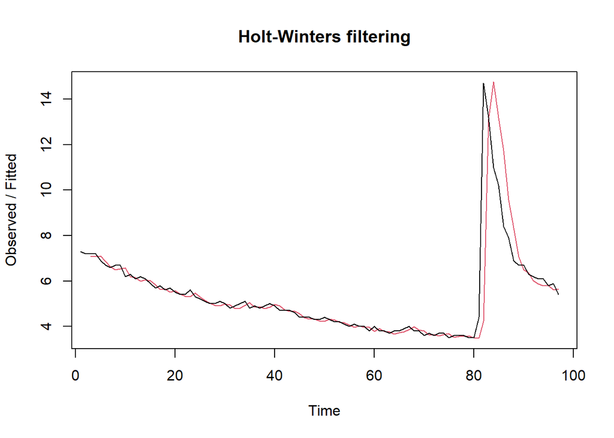

```r
#Lamda=0.6 dan gamma=0.3
des.2<- HoltWinters(train.ts, gamma = FALSE, beta = 0.2, alpha = 0.7)
plot(des.2)
```

```r
#ramalan
ramalandes2<- forecast(des.2, h=24)
ramalandes2
```

```
##     Point Forecast       Lo 80     Hi 80       Lo 95     Hi 95
##  98      5.2848608   3.6588774  6.910844   2.7981338  7.771588
##  99      5.0929325   2.9694206  7.216444   1.8453013  8.340564
## 100      4.9010042   2.2461163  7.555892   0.8407036  8.961305
## 101      4.7090759   1.4896287  7.928523  -0.2146436  9.632795
## 102      4.5171476   0.7011062  8.333189  -1.3189841 10.353279
## 103      4.3252193  -0.1182099  8.768648  -2.4704192 11.120858
## 104      4.1332910  -0.9671160  9.233698  -3.6671083 11.933690
## 105      3.9413627  -1.8444886  9.727214  -4.9073332 12.790059
## 106      3.7494344  -2.7492940 10.248163  -6.1895130 13.688382
## 107      3.5575061  -3.6805860 10.795598  -7.5122005 14.627213
## 108      3.3655778  -4.6374987 11.368654  -8.8740714 15.605227
## 109      3.1736495  -5.6192382 11.966537 -10.2739118 16.621211
## 110      2.9817212  -6.6250754 12.588518 -11.7106062 17.674049
## 111      2.7897929  -7.6543379 13.233924 -13.1831267 18.762712
## 112      2.5978646  -8.7064043 13.902133 -14.6905227 19.886252
## 113      2.4059363  -9.7806982 14.592571 -16.2319127 21.043785
## 114      2.2140080 -10.8766833 15.304699 -17.8064767 22.234493
## 115      2.0220796 -11.9938595 16.038019 -19.4134496 23.457609
## 116      1.8301513 -13.1317588 16.792062 -21.0521156 24.712418
## 117      1.6382230 -14.2899422 17.566388 -22.7218036 25.998250
## 118      1.4462947 -15.4679971 18.360587 -24.4218823 27.314472
## 119      1.2543664 -16.6655346 19.174267 -26.1517572 28.660490
## 120      1.0624381 -17.8821875 20.007064 -27.9108665 30.035743
## 121      0.8705098 -19.1176083 20.858628 -29.6986789 31.439699
```

Selanjutnya jika ingin membandingkan plot data latih dan data uji adalah sebagai berikut.

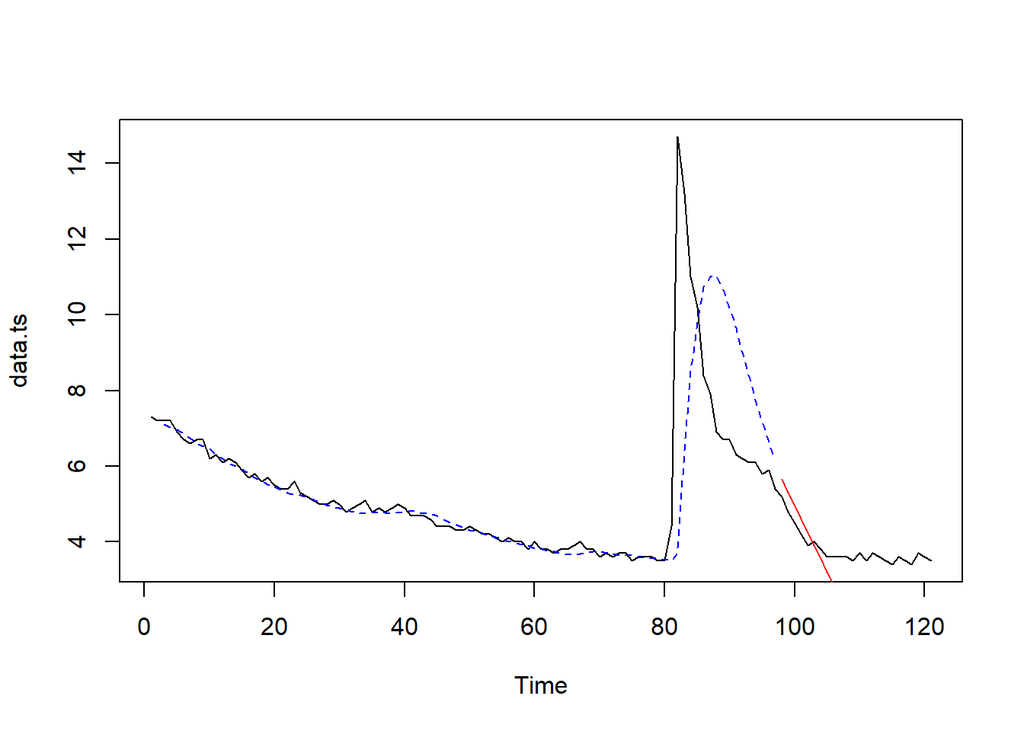

```r
#Visually evaluate the prediction
plot(data.ts)
lines(des.1$fitted[,1], lty=2, col="blue")
lines(ramalandes1$mean, col="red")
```

Untuk mendapatkan nilai parameter optimum dari DES, argumen `alpha` dan `beta` dapat dibuat `NULL` seperti berikut.

```r
#Lamda dan gamma optimum
des.opt<- HoltWinters(train.ts, gamma = FALSE)
des.opt
```

```
## Holt-Winters exponential smoothing with trend and without seasonal component.
##
## Call:
## HoltWinters(x = train.ts, gamma = FALSE)
##
## Smoothing parameters:
##  alpha: 1
##  beta : 0
##  gamma: FALSE
##
## Coefficients:
##   [,1]
## a  5.4
## b -0.1
```

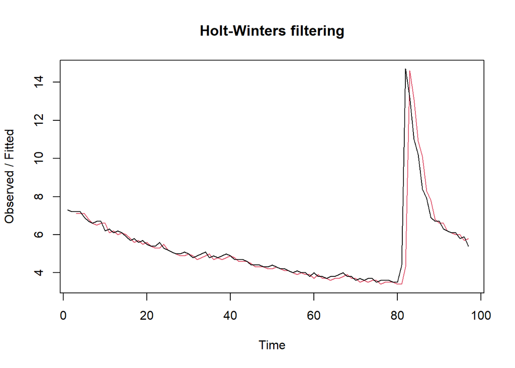

```r
plot(des.opt)
```

```r
#ramalan
ramalandesopt<- forecast(des.opt, h=24)
ramalandesopt
```

```
##     Point Forecast      Lo 80     Hi 80       Lo 95     Hi 95
##  98            5.3  3.8447620  6.755238  3.07440552  7.525594
##  99            5.2  3.1419827  7.258017  2.05253410  8.347466
## 100            5.1  2.5794538  7.620546  1.24515729  8.954843
## 101            5.0  2.0895240  7.910476  0.54881104  9.451189
## 102            4.9  1.6459889  8.154011 -0.07658054  9.876581
## 103            4.8  1.2354094  8.364591 -0.65157085 10.251571
## 104            4.7  0.8498021  8.550198 -1.18836951 10.588370
## 105            4.6  0.4839653  8.716035 -1.69493179 10.894932
## 106            4.5  0.1342860  8.865714 -2.17678343 11.176783
## 107            4.4 -0.2018666  9.001867 -2.63794770 11.437948
## 108            4.3 -0.5264785  9.126478 -3.08146182 11.681462
## 109            4.2 -0.8410923  9.241092 -3.50968543 11.909685
## 110            4.1 -1.1469353  9.346935 -3.92449501 12.124495
## 111            4.0 -1.4450020  9.445002 -4.32741202 12.327412
## 112            3.9 -1.7361126  9.536113 -4.71969035 12.519690
## 113            3.8 -2.0209520  9.620952 -5.10237791 12.702378
## 114            3.7 -2.3001000  9.700100 -5.47636111 12.876361
## 115            3.6 -2.5740520  9.774052 -5.84239769 13.042398
## 116            3.5 -2.8432354  9.843235 -6.20114142 13.201141
## 117            3.4 -3.1080222  9.908022 -6.55316109 13.353161
## 118            3.3 -3.3687383  9.968738 -6.89895516 13.498955
## 119            3.2 -3.6256713 10.025671 -7.23896342 13.638963
## 120            3.1 -3.8790763 10.079076 -7.57357616 13.773576
## 121            3.0 -4.1291812 10.129181 -7.90314169 13.903142
```

Selanjutnya akan dilakukan perhitungan akurasi pada data latih maupun data uji dengan ukuran akurasi SSE, MSE dan MAPE.

### Akurasi Data Latih

```r
#Akurasi Data Training
ssedes.train1<-des.1$SSE
msedes.train1<-ssedes.train1/length(train.ts)
sisaandes1<-ramalandes1$residuals
head(sisaandes1)
```

```
## Time Series:
## Start = 1
## End = 6
## Frequency = 1
## [1]         NA         NA  0.1000000  0.1760000 -0.0702400 -0.1644224
```

```r
mapedes.train1 <- sum(abs(sisaandes1[3:length(train.ts)]/train.ts[3:length(train.ts)])
                      *100)/length(train.ts)

akurasides.1 <- matrix(c(ssedes.train1,msedes.train1,mapedes.train1))
row.names(akurasides.1)<- c("SSE", "MSE", "MAPE")
colnames(akurasides.1) <- c("Akurasi lamda=0.2 dan gamma=0.2")
akurasides.1
```

```
##      Akurasi lamda=0.2 dan gamma=0.2
## SSE                       266.632058
## MSE                         2.748784
## MAPE                        8.167691
```

```r
ssedes.train2<-des.2$SSE
msedes.train2<-ssedes.train2/length(train.ts)
sisaandes2<-ramalandes2$residuals
head(sisaandes2)
```

```
## Time Series:
## Start = 1
## End = 6
## Frequency = 1
## [1]         NA         NA  0.1000000  0.1160000 -0.1954400 -0.1615104
```

```r
mapedes.train2 <- sum(abs(sisaandes2[3:length(train.ts)]/train.ts[3:length(train.ts)])
                      *100)/length(train.ts)

akurasides.2 <- matrix(c(ssedes.train2,msedes.train2,mapedes.train2))
row.names(akurasides.2)<- c("SSE", "MSE", "MAPE")
colnames(akurasides.2) <- c("Akurasi lamda=0.7 dan gamma=0.2")
akurasides.2
```

```
##      Akurasi lamda=0.7 dan gamma=0.2
## SSE                       151.321600
## MSE                         1.560016
## MAPE                        4.560536
```

Hasil akurasi dari data latih didapatkan skenario 2 dengan lamda=0.7 dan gamma=0.2 memiliki hasil yang lebih baik. Namun untuk kedua skenario dapat dikategorikan peramalan sangat baik berdasarkan nilai MAPE-nya.

### Akurasi Data Uji

```r
#Akurasi Data Testing
selisihdes1<-ramalandes1$mean-testing$rate
selisihdes1
```

```
## Time Series:
## Start = 98
## End = 121
## Frequency = 1
##  [1]  0.45332602  0.50377283  0.45421964  0.40466645  0.35511326 -0.09443993
##  [7] -0.24399312 -0.39354631 -0.74309951 -1.09265270 -1.44220589 -1.69175908
## [13] -2.24131227 -2.39086546 -2.94041865 -3.18997184 -3.43952503 -3.68907823
## [19] -4.23863142 -4.48818461 -4.73773780 -5.38729099 -5.63684418 -5.88639737
```

```r
SSEtestingdes1<-sum(selisihdes1^2)
MSEtestingdes1<-SSEtestingdes1/length(testing$rate)
MAPEtestingdes1<-sum(abs(selisihdes1/testing$rate)*100)/length(testing$rate)

selisihdes2<-ramalandes2$mean-testing$rate
selisihdes2
```

```
## Time Series:
## Start = 98
## End = 121
## Frequency = 1
##  [1]  0.08486078  0.29293248  0.40100417  0.50907587  0.61714757  0.32521927
##  [7]  0.33329097  0.34136267  0.14943436 -0.04249394 -0.23442224 -0.32635054
## [13] -0.71827884 -0.71020714 -1.10213545 -1.19406375 -1.28599205 -1.37792035
## [19] -1.76984865 -1.86177696 -1.95370526 -2.44563356 -2.53756186 -2.62949016
```

```r
SSEtestingdes2<-sum(selisihdes2^2)
MSEtestingdes2<-SSEtestingdes2/length(testing$rate)
MAPEtestingdes2<-sum(abs(selisihdes2/testing$rate)*100)/length(testing$rate)

selisihdesopt<-ramalandesopt$mean-testing$rate
selisihdesopt
```

```
## Time Series:
## Start = 98
## End = 121
## Frequency = 1
##  [1]  0.1  0.4  0.6  0.8  1.0  0.8  0.9  1.0  0.9  0.8  0.7  0.7  0.4  0.5  0.2
## [16]  0.2  0.2  0.2 -0.1 -0.1 -0.1 -0.5 -0.5 -0.5
```

```r
SSEtestingdesopt<-sum(selisihdesopt^2)
MSEtestingdesopt<-SSEtestingdesopt/length(testing$rate)
MAPEtestingdesopt<-sum(abs(selisihdesopt/testing$rate)*100)/length(testing$rate)

akurasitestingdes <-
  matrix(c(SSEtestingdes1,MSEtestingdes1,MAPEtestingdes1,SSEtestingdes2,MSEtestingdes2,
           MAPEtestingdes2,SSEtestingdesopt,MSEtestingdesopt,MAPEtestingdesopt),
         nrow=3,ncol=3)
row.names(akurasitestingdes)<- c("SSE", "MSE", "MAPE")
colnames(akurasitestingdes) <- c("des ske1","des ske2","des opt")
akurasitestingdes
```

```
##        des ske1  des ske2  des opt
## SSE  218.870770 38.376172  8.40000
## MSE    9.119615  1.599007  0.35000
## MAPE  65.274016 26.816854 13.51356
```

# Perbandingan SES dan DES

```r
MSEfull <-
  matrix(c(MSEtesting1,MSEtesting2,MSEtestingopt,MSEtestingdes1,MSEtestingdes2,
           MSEtestingdesopt),nrow=3,ncol=2)
row.names(MSEfull)<- c("ske 1", "ske 2", "ske opt")
colnames(MSEfull) <- c("ses","des")
MSEfull
```

```
##              ses      des
## ske 1   73.05729 9.119615
## ske 2   37.32622 1.599007
## ske opt 33.41143 0.350000
```

Berdasarkan hasil yang didapatkan dapat dilihat bahwa metode DES lebih baik digunakan dibandingkan dengan SES pada data yang berpola trend